# Dice_Game_using_Dynamic_Programming

### `---------------Mandatory Information to fill------------`

### Group ID: 88

### Group Members Name with Student ID:

1. Student 1: SIGINAM SIVASAI, ID: 2023AA05371
2. Student 2: PEYALA SAMARASIMHA REDDY, ID: 2023AA05072
3. Student 3: PEGALLAPATI SAI MAHARSHI, ID: 2023AA05924
4. Student 4: CHADALAWADA VISWANATH HEMANTH, ID: 2023AA05195

`-------------------Write your remarks (if any) that you want should get consider at the time of evaluation---------------`

# Problem Statement

Develop a reinforcement learning agent using dynamic programming methods to solve the Dice game optimally. The agent will learn the optimal policy by iteratively evaluating and improving its strategy based on the state-value function and the Bellman equations.

# Scenario:

A player rolls a 6-sided die with the objective of reaching a score of **exactly** 100. On each turn, the player can choose to stop and keep their current score or continue rolling the die. If the player rolls a 1, they lose all points accumulated in that turn and the turn ends. If the player rolls any other number (2-6), that number is added to their score for that turn. The game ends when the player decides to stop and keep their score OR when the player's score reaches 100. The player wins if they reach a score of exactly 100, and loses if they roll a 1 when their score is below 100.

# Environment Details

- The environment consists of a player who can choose to either roll a 6-sided die or stop at any point.
- The player starts with an initial score (e.g., 0) and aims to reach a score of exactly 100.
- If the player rolls a 1, they lose all points accumulated in that turn and the turn ends. If they roll any other number (2-6), that number is added to their score for that turn.
- The goal is to accumulate a total of exactly 100 points to win, or to stop the game before reaching 100 points.

#### States

- State s: Represents the current score of the player, ranging from 0 to 100.
- Terminal States:
  - State s = 100: Represents the player winning the game by reaching the goal of 100 points.
  - State s = 0: Represents the player losing all points accumulated in the turn due to rolling a 1.

#### Actions

- Action a: Represents the decision to either "roll" the die or "stop" the game at the current score.
- The possible actions in any state s are either "roll" or "stop".

# Expected Outcomes:

1. Use dynamic programming methods value iteration, policy improvement and policy evaluation to find the optimal policy for the Dice Game.
2. Implement an epsilon-greedy policy for action selection during training to balance exploration and exploitation.
3. Evaluate the agent's performance in terms of the probability of reaching exactly 100 points after learning the optimal policy.
4. Use the agent's policy as the best strategy for different betting scenarios within the problem.

# Code Execution

### Initialize constants

```python
# Importing the necessary libraries
import numpy as np
import matplotlib.pyplot as plt
import seaborn as sns
```

```python
# Constants
goal = 100
gamma = 1.0
prob_roll = 1/6

# Initialize value function and policy
V = np.zeros(goal + 1)
policy = np.zeros(goal + 1, dtype=int)  # 0 for "stop", 1 for "roll"
```

# Design a DiceGame Environment (1M)

```python
# Code for Dataset loading and print dataset statistics along with reward function
#-----write your code below this line---------

# Define the environment class for the Dice game
class DiceGameEnvironment:
    def __init__(self, goal=100):
        self.goal = goal
        self.state = 0

    def reset(self):
        self.state = 0
        return self.state

    def step(self, action):
        if action == "stop":
            return self.state, 0, True

        roll = np.random.randint(1, 7)
        if roll == 1:
            return 0, -self.state, True
        else:
            self.state += roll
            if self.state == self.goal:
                return self.state, self.goal, True
            return self.state, roll, False
```

### Define reward funtion

```python
#Calculate reward function for 'stop' and 'roll' actions
#-----write your code below this line---------
def reward_function(state, action):
    if action == "stop":
        return state if state == goal else -state
    else:
        return 0
```

# Policy Iteration Function Definition (0.5M)

```python
#For each state, Store old_policy of state s.
#Determine best_action based on maximum reward. Update policy[s] to best_action.
#Return stable when old policy = policy[s]

#-----write your code below this line---------
def policy_iteration(env, gamma=1.0, theta=1e-6):
    policy = np.zeros(goal + 1, dtype=int)
    V = np.zeros(goal + 1)
    stable = False

    while not stable:
        # Policy Evaluation
        while True:
            delta = 0
            for s in range(goal + 1):
                v = V[s]
                if policy[s] == 0:  # stop
                    V[s] = reward_function(s, "stop")
                else:  # roll
                    V[s] = sum(prob_roll * (reward_function(s, "roll") + gamma * V[min(s + i, goal)])
                               for i in range(2, 7))
                delta = max(delta, abs(v - V[s]))
            if delta < theta:
                break

        # Policy Improvement
        stable = True
        for s in range(goal + 1):
            old_action = policy[s]
            action_values = [
                reward_function(s, "stop"),
                sum(prob_roll * (reward_function(s, "roll") + gamma * V[min(s + i, goal)]) for i in range(2, 7))
            ]
            policy[s] = np.argmax(action_values)
            if old_action != policy[s]:
                stable = False
    return policy, V
```

# Value Iteration Function Definition (0.5M)

```python
# Iterate over all states except terminal state untill convergence

# Calculate expected returns V(s) for current policy by considering all possible actions.

#If action is stop:
        #Calculate reward for stopping and append to rewards.
#If action is roll:
        #For each possible roll outcome (1 to 6), Determine next_s based on roll.

# Update V(s) using the Bellman equation.

#Determine max_reward from rewards
#With probability epsilon, randomly choose a reward from rewards.

#Check convergence if delta is less than a small threshold.

#-----write your code below this line---------

def value_iteration(env, gamma=1.0, theta=1e-6):
    V = np.zeros(goal + 1)
    policy = np.zeros(goal + 1, dtype=int)

    while True:
        delta = 0
        for s in range(goal + 1):
            v = V[s]
            action_values = [
                reward_function(s, "stop"),
                sum(prob_roll * (reward_function(s, "roll") + gamma * V[min(s + i, goal)]) for i in range(2, 7))
            ]
            V[s] = max(action_values)
            delta = max(delta, abs(v - V[s]))
        if delta < theta:
            break

    for s in range(goal + 1):
        action_values = [
            reward_function(s, "stop"),
            sum(prob_roll * (reward_function(s, "roll") + gamma * V[min(s + i, goal)]) for i in range(2, 7))
        ]
        policy[s] = np.argmax(action_values)

    return policy, V
```

# Executing Policy Iteration and Value Iteration Functions (1M)

```python
#Simulate the game for 100 states. Use the learned policy to get the actions.
#when its roll, randomly generate a number to find the reward.
#when its stop, get the respective reward
#determine the total cumulative reward

#-----write your code below this line---------
# Instantiate the environment
env = DiceGameEnvironment(goal)

# Policy Iteration
optimal_policy_pi, optimal_value_pi = policy_iteration(env)
print("Policy Iteration Optimal Policy:", optimal_policy_pi)
print("Policy Iteration Optimal Value Function:", optimal_value_pi)

# Value Iteration
optimal_policy_vi, optimal_value_vi = value_iteration(env)
print("Value Iteration Optimal Policy:", optimal_policy_vi)
print("Value Iteration Optimal Value Function:", optimal_value_vi)
```

```
Policy Iteration Optimal Policy: [1 1 1 1 1 1 1 1 1 1 1 1 1 1 1 1 1 1 1 1 1 1 1 1 1 1 1 1 1 1 1 1 1 1 1 1 1
 1 1 1 1 1 1 1 1 1 1 1 1 1 1 1 1 1 1 1 1 1 1 1 1 1 1 1 1 1 1 1 1 1 1 1 1 1
 1 1 1 1 1 1 1 1 1 1 1 1 1 1 1 1 1 1 1 1 1 1 1 1 1 1 0]
Policy Iteration Optimal Value Function: [  1.01969827   1.06671037   1.11588992   1.16733683   1.22115566
   1.27745574   1.33635147   1.39796253   1.46241411   1.52983715
   1.60036867   1.67415196   1.75133695   1.83208048   1.9165466
   2.00490694   2.09734104   2.19403671   2.29519044   2.40100775
   2.51170365   2.62750307   2.7486413    2.87536448   3.0079301
   3.14660752   3.2916785    3.44343784   3.60219387   3.76826918
   3.94200122   4.12374299   4.31386377   4.51274986   4.72080539
   4.93845309   5.16613521   5.40431438   5.65347454   5.91412195
   6.18678624   6.47202144   6.77040712   7.08254953   7.40908289
   7.75067072   8.10800718   8.4818183    8.87286362   9.28193737
   9.70987088  10.15753414  10.62583706  11.11573034  11.62820929
  12.16431336  12.72513523  13.31181665  13.92554785  14.56756893
  15.23918707  15.94175965  16.67674786  17.44563637  18.24995617
  19.09131354  19.97146847  20.89218337  21.85556564  22.86328721
  23.91723235  25.0196127   26.17311292  27.37985502  28.64358083
  29.96356177  31.34328356  32.78739501  34.30085634  35.88403347
  37.54591658  39.26316921  41.06572574  42.96552506  44.96480148
  47.04497933  49.23446788  51.36924154  53.7808642   56.36359739
  59.04063786  61.71553498  64.50617284  66.58950617  70.83333333
  74.53703704  77.77777778  80.55555556  83.33333333  83.33333333
 100.        ]
Value Iteration Optimal Policy: [1 1 1 1 1 1 1 1 1 1 1 1 1 1 1 1 1 1 1 1 1 1 1 1 1 1 1 1 1 1 1 1 1 1 1 1 1
 1 1 1 1 1 1 1 1 1 1 1 1 1 1 1 1 1 1 1 1 1 1 1 1 1 1 1 1 1 1 1 1 1 1 1 1 1
 1 1 1 1 1 1 1 1 1 1 1 1 1 1 1 1 1 1 1 1 1 1 1 1 1 1 0]
Value Iteration Optimal Value Function: [  1.01969823   1.06671036   1.11588991   1.16733683   1.22115565
   1.27745574   1.33635147   1.39796253   1.46241411   1.52983715
   1.60036867   1.67415196   1.75133695   1.83208048   1.9165466
   2.00490694   2.09734104   2.19403671   2.29519044   2.40100775
   2.51170365   2.62750307   2.7486413    2.87536448   3.0079301
   3.14660752   3.2916785    3.44343784   3.60219387   3.76826918
   3.94200122   4.12374299   4.31386377   4.51274986   4.72080539
   4.93845309   5.16613521   5.40431438   5.65347454   5.91412195
   6.18678624   6.47202144   6.77040712   7.08254953   7.40908289
   7.75067072   8.10800718   8.4818183    8.87286362   9.28193737
   9.70987088  10.15753414  10.62583706  11.11573034  11.62820929
  12.16431336  12.72513523  13.31181665  13.92554785  14.56756893
  15.23918707  15.94175965  16.67674786  17.44563637  18.24995617
  19.09131354  19.97146847  20.89218337  21.85556564  22.86328721
  23.91723235  25.0196127   26.17311292  27.37985502  28.64358083
  29.96356177  31.34328356  32.78739501  34.30085634  35.88403347
  37.54591658  39.26316921  41.06572574  42.96552506  44.96480148
  47.04497933  49.23446788  51.36924154  53.7808642   56.36359739
  59.04063786  61.71553498  64.50617284  66.58950617  70.83333333
  74.53703704  77.77777778  80.55555556  83.33333333  83.33333333
 100.        ]
```

### Print the Learned Optimal Policy, Optimal Value Function (0.5M)

```python
#-----write your code below this line---------
print("Learned Optimal Policy (Policy Iteration):", optimal_policy_pi)
print("Learned Optimal Value Function (Policy Iteration):", optimal_value_pi)

print("Learned Optimal Policy (Value Iteration):", optimal_policy_vi)
print("Learned Optimal Value Function (Value Iteration):", optimal_value_vi)
```

```
Learned Optimal Policy (Policy Iteration): [1 1 1 1 1 1 1 1 1 1 1 1 1 1 1 1 1 1 1 1 1 1 1 1 1 1 1 1 1 1 1 1 1 1 1 1 1
 1 1 1 1 1 1 1 1 1 1 1 1 1 1 1 1 1 1 1 1 1 1 1 1 1 1 1 1 1 1 1 1 1 1 1 1 1
 1 1 1 1 1 1 1 1 1 1 1 1 1 1 1 1 1 1 1 1 1 1 1 1 1 1 0]
Learned Optimal Value Function (Policy Iteration): [  1.01969827   1.06671037   1.11588992   1.16733683   1.22115566
   1.27745574   1.33635147   1.39796253   1.46241411   1.52983715
   1.60036867   1.67415196   1.75133695   1.83208048   1.9165466
   2.00490694   2.09734104   2.19403671   2.29519044   2.40100775
   2.51170365   2.62750307   2.7486413    2.87536448   3.0079301
   3.14660752   3.2916785    3.44343784   3.60219387   3.76826918
   3.94200122   4.12374299   4.31386377   4.51274986   4.72080539
   4.93845309   5.16613521   5.40431438   5.65347454   5.91412195
   6.18678624   6.47202144   6.77040712   7.08254953   7.40908289
   7.75067072   8.10800718   8.4818183    8.87286362   9.28193737
   9.70987088  10.15753414  10.62583706  11.11573034  11.62820929
  12.16431336  12.72513523  13.31181665  13.92554785  14.56756893
  15.23918707  15.94175965  16.67674786  17.44563637  18.24995617
  19.09131354  19.97146847  20.89218337  21.85556564  22.86328721
  23.91723235  25.0196127   26.17311292  27.37985502  28.64358083
  29.96356177  31.34328356  32.78739501  34.30085634  35.88403347
  37.54591658  39.26316921  41.06572574  42.96552506  44.96480148
  47.04497933  49.23446788  51.36924154  53.7808642   56.36359739
  59.04063786  61.71553498  64.50617284  66.58950617  70.83333333
  74.53703704  77.77777778  80.55555556  83.33333333  83.33333333
 100.        ]
Learned Optimal Policy (Value Iteration): [1 1 1 1 1 1 1 1 1 1 1 1 1 1 1 1 1 1 1 1 1 1 1 1 1 1 1 1 1 1 1 1 1 1 1 1 1
 1 1 1 1 1 1 1 1 1 1 1 1 1 1 1 1 1 1 1 1 1 1 1 1 1 1 1 1 1 1 1 1 1 1 1 1 1
 1 1 1 1 1 1 1 1 1 1 1 1 1 1 1 1 1 1 1 1 1 1 1 1 1 1 0]
Learned Optimal Value Function (Value Iteration): [  1.01969823   1.06671036   1.11588991   1.16733683   1.22115565
   1.27745574   1.33635147   1.39796253   1.46241411   1.52983715
   1.60036867   1.67415196   1.75133695   1.83208048   1.9165466
   2.00490694   2.09734104   2.19403671   2.29519044   2.40100775
   2.51170365   2.62750307   2.7486413    2.87536448   3.0079301
   3.14660752   3.2916785    3.44343784   3.60219387   3.76826918
   3.94200122   4.12374299   4.31386377   4.51274986   4.72080539
   4.93845309   5.16613521   5.40431438   5.65347454   5.91412195
   6.18678624   6.47202144   6.77040712   7.08254953   7.40908289
   7.75067072   8.10800718   8.4818183    8.87286362   9.28193737
   9.70987088  10.15753414  10.62583706  11.11573034  11.62820929
  12.16431336  12.72513523  13.31181665  13.92554785  14.56756893
  15.23918707  15.94175965  16.67674786  17.44563637  18.24995617
  19.09131354  19.97146847  20.89218337  21.85556564  22.86328721
  23.91723235  25.0196127   26.17311292  27.37985502  28.64358083
  29.96356177  31.34328356  32.78739501  34.30085634  35.88403347
  37.54591658  39.26316921  41.06572574  42.96552506  44.96480148
  47.04497933  49.23446788  51.36924154  53.7808642   56.36359739
  59.04063786  61.71553498  64.50617284  66.58950617  70.83333333
  74.53703704  77.77777778  80.55555556  83.33333333  83.33333333
 100.        ]
```

# Change in environment details (1M)

Consider the following scenario:

1. What happens if we change the goal score to 50 instead of 100? How does it affect the optimal policy and value function?
2. How would the optimal policy and value function change if the die had 8 sides instead of 6? Assume the outcomes range from 0 to 7, with each outcome having a probability of 1/8.
3. Experiment with different discount factors (e.g., 0.9, 0.95). How does discounting future rewards impact the optimal policy and value function?
4. Create a heatmap or line plot to visualize the value function over different states. How does the value function change as the state approaches the goal?

```python
#-----write your code below this line---------
# 1. What happens if we change the goal score to 50 instead of 100? How does it affect the optimal policy and value function?
env_50 = DiceGameEnvironment(goal=50)
optimal_policy_50, optimal_value_50 = value_iteration(env_50)
print("Value Iteration Optimal Policy with goal 50:", optimal_policy_50)
print("Value Iteration Optimal Value Function with goal 50:", optimal_value_50)
```

```
Value Iteration Optimal Policy with goal 50: [1 1 1 1 1 1 1 1 1 1 1 1 1 1 1 1 1 1 1 1 1 1 1 1 1 1 1 1 1 1 1 1 1 1 1 1 1
 1 1 1 1 1 1 1 1 1 1 1 1 1 1 1 1 1 1 1 1 1 1 1 1 1 1 1 1 1 1 1 1 1 1 1 1 1
 1 1 1 1 1 1 1 1 1 1 1 1 1 1 1 1 1 1 1 1 1 1 1 1 1 1 0]
Value Iteration Optimal Value Function with goal 50: [  1.01969823   1.06671036   1.11588991   1.16733683   1.22115565
   1.27745574   1.33635147   1.39796253   1.46241411   1.52983715
   1.60036867   1.67415196   1.75133695   1.83208048   1.9165466
   2.00490694   2.09734104   2.19403671   2.29519044   2.40100775
   2.51170365   2.62750307   2.7486413    2.87536448   3.0079301
   3.14660752   3.2916785    3.44343784   3.60219387   3.76826918
   3.94200122   4.12374299   4.31386377   4.51274986   4.72080539
   4.93845309   5.16613521   5.40431438   5.65347454   5.91412195
   6.18678624   6.47202144   6.77040712   7.08254953   7.40908289
   7.75067072   8.10800718   8.4818183    8.87286362   9.28193737
   9.70987088  10.15753414  10.62583706  11.11573034  11.62820929
  12.16431336  12.72513523  13.31181665  13.92554785  14.56756893
  15.23918707  15.94175965  16.67674786  17.44563637  18.24995617
  19.09131354  19.97146847  20.89218337  21.85556564  22.86328721
  23.91723235  25.0196127   26.17311292  27.37985502  28.64358083
  29.96356177  31.34328356  32.78739501  34.30085634  35.88403347
  37.54591658  39.26316921  41.06572574  42.96552506  44.96480148
  47.04497933  49.23446788  51.36924154  53.7808642   56.36359739
  59.04063786  61.71553498  64.50617284  66.58950617  70.83333333
  74.53703704  77.77777778  80.55555556  83.33333333  83.33333333
 100.        ]
```

```python
# 2. How would the optimal policy and value function change if the die had 8 sides instead of 6? Assume the outcomes range from 0 to 7, with each outcome having a probability of 1/8.
def reward_function_8_sides(state, action):
    if action == "stop":
        return state if state == goal else -state
    else:
        return 0

def value_iteration_8_sides(env, gamma=1.0, theta=1e-6):
    V = np.zeros(goal + 1)
    policy = np.zeros(goal + 1, dtype=int)
    prob_roll = 1/8

    while True:
        delta = 0
        for s in range(goal + 1):
            v = V[s]
            action_values = [
                reward_function_8_sides(s, "stop"),
                sum(prob_roll * (reward_function_8_sides(s, "roll") + gamma * V[min(s + i, goal)]) for i in range(1, 8))
            ]
            V[s] = max(action_values)
            delta = max(delta, abs(v - V[s]))
        if delta < theta:
            break


    for s in range(goal + 1):
        action_values = [
            reward_function_8_sides(s, "stop"),
            sum(prob_roll * (reward_function_8_sides(s, "roll") + gamma * V[min(s + i, goal)]) for i in range(1, 8))
        ]
        policy[s] = np.argmax(action_values)

    return policy, V

optimal_policy_8_sides, optimal_value_8_sides = value_iteration_8_sides(env)
print("Value Iteration Optimal Policy with 8-sided die:", optimal_policy_8_sides)
print("Value Iteration Optimal Value Function with 8-sided die:", optimal_value_8_sides)
```

```
Value Iteration Optimal Policy with 8-sided die: [1 1 1 1 1 1 1 1 1 1 1 1 1 1 1 1 1 1 1 1 1 1 1 1 1 1 1 1 1 1 1 1 1 1 1 1 1
 1 1 1 1 1 1 1 1 1 1 1 1 1 1 1 1 1 1 1 1 1 1 1 1 1 1 1 1 1 1 1 1 1 1 1 1 1
 1 1 1 1 1 1 1 1 1 1 1 1 1 1 1 1 1 1 1 1 1 1 1 1 1 1 0]
Value Iteration Optimal Value Function with 8-sided die: [  3.50834557   3.62548594   3.7465375    3.87163083   4.0009009
   4.13448717   4.27253375   4.41518957   4.56260853   4.71494967
   4.87237733   5.03506136   5.20317724   5.37690635   5.55643612
   5.74196021   5.93367877   6.13179863   6.33653353   6.54810432
   6.76673927   6.99267422   7.22615293   7.46742727   7.71675752
   7.97441268   8.2406707    8.51581881   8.80015386   9.09398258
   9.39762197   9.71139959  10.03565394  10.37073483  10.71700373
  11.07483423  11.44461237  11.82673707  12.22162054  12.62968875
  13.05138191  13.48715498  13.93747822  14.40283747  14.88373467
  15.38068834  15.89423444  16.42492714  16.97333958  17.54006408
  18.12571155  18.73091225  19.35631773  20.00260316  20.67046874
  21.36063915  22.07386004  22.81089132  23.57251785  24.35956158
  25.17288659  26.01339343  26.88200237  27.77962715  28.70714157
  29.66553009  30.65591144  31.6794867   32.73744812  33.8308739
  34.96062537  36.12725697  37.33263824  38.57896223  39.86808875
  41.20113952  42.57828013  43.99863708  45.46030981  46.97568837
  48.54955421  50.18110084  51.86554568  53.59540508  55.36149269
  57.15369163  59.09871683  61.14048097  63.23347386  65.34110437
  67.43428027  69.49019358  71.49128318  74.65891838  77.47459412
  79.97741699  82.20214844  84.1796875   85.9375      87.5
 100.        ]
```

```python
# 3. Experiment with different discount factors (e.g., 0.9, 0.95). How does discounting future rewards impact the optimal policy and value function?
# Experiment with different discount factors
gamma_values = [0.9, 0.95]
for gamma in gamma_values:
    optimal_policy_gamma, optimal_value_gamma = value_iteration(env, gamma=gamma)
    print(f"Value Iteration Optimal Policy with gamma {gamma}:", optimal_policy_gamma)
    print(f"Value Iteration Optimal Value Function with gamma {gamma}:", optimal_value_gamma)
```

```
Value Iteration Optimal Policy with gamma 0.9: [1 1 1 1 1 1 1 1 1 1 1 1 1 1 1 1 1 1 1 1 1 1 1 1 1 1 1 1 1 1 1 1 1 1 1 1 1
 1 1 1 1 1 1 1 1 1 1 1 1 1 1 1 1 1 1 1 1 1 1 1 1 1 1 1 1 1 1 1 1 1 1 1 1 1
 1 1 1 1 1 1 1 1 1 1 1 1 1 1 1 1 1 1 1 1 1 1 1 1 1 1 0]
Value Iteration Optimal Value Function with gamma 0.9: [7.54281529e-02 8.09518476e-02 8.68800194e-02 9.32422990e-02
 1.00070483e-01 1.07398692e-01 1.15263547e-01 1.23704347e-01
 1.32763270e-01 1.42485582e-01 1.52919862e-01 1.64118249e-01
 1.76136699e-01 1.89035265e-01 2.02878398e-01 2.17735270e-01
 2.33680117e-01 2.50792612e-01 2.69158262e-01 2.88868837e-01
 3.10022825e-01 3.32725930e-01 3.57091592e-01 3.83241562e-01
 4.11306506e-01 4.41426657e-01 4.73752520e-01 5.08445620e-01
 5.45679310e-01 5.85639639e-01 6.28526281e-01 6.74553530e-01
 7.23951374e-01 7.76966642e-01 8.33864241e-01 8.94928476e-01
 9.60464473e-01 1.03079970e+00 1.10628560e+00 1.18729936e+00
 1.27424580e+00 1.36755937e+00 1.46770635e+00 1.57518711e+00
 1.69053871e+00 1.81433755e+00 1.94720230e+00 2.08979682e+00
 2.24283361e+00 2.40707712e+00 2.58334818e+00 2.77252793e+00
 2.97556182e+00 3.19346377e+00 3.42732236e+00 3.67830494e+00
 3.94766833e+00 4.23676015e+00 4.54702305e+00 4.88000198e+00
 5.23736220e+00 5.62088554e+00 6.03251610e+00 6.47430185e+00
 6.94842128e+00 7.45722178e+00 8.00328701e+00 8.58933834e+00
 9.21850560e+00 9.89365958e+00 1.06180180e+01 1.13952904e+01
 1.22297732e+01 1.31255144e+01 1.40881080e+01 1.51190445e+01
 1.62243463e+01 1.74115892e+01 1.86887335e+01 2.00597160e+01
 2.15363349e+01 2.30972562e+01 2.47802681e+01 2.66036863e+01
 2.85740114e+01 3.06762182e+01 3.29413816e+01 3.51864105e+01
 3.78237656e+01 4.07301328e+01 4.38117187e+01 4.69560937e+01
 5.02875000e+01 5.27906250e+01 5.83125000e+01 6.31875000e+01
 6.75000000e+01 7.12500000e+01 7.50000000e+01 7.50000000e+01
 1.00000000e+02]
Value Iteration Optimal Policy with gamma 0.95: [1 1 1 1 1 1 1 1 1 1 1 1 1 1 1 1 1 1 1 1 1 1 1 1 1 1 1 1 1 1 1 1 1 1 1 1 1
 1 1 1 1 1 1 1 1 1 1 1 1 1 1 1 1 1 1 1 1 1 1 1 1 1 1 1 1 1 1 1 1 1 1 1 1 1
 1 1 1 1 1 1 1 1 1 1 1 1 1 1 1 1 1 1 1 1 1 1 1 1 1 1 0]
Value Iteration Optimal Value Function with gamma 0.95: [  0.28583748   0.30277776   0.320722     0.3397297    0.3598639
   0.38119135   0.40378277   0.42771309   0.45306164   0.47991248
   0.50835465   0.53848245   0.57039578   0.60420047   0.6400086
   0.67793891   0.71811718   0.76067662   0.80575836   0.85351188
   0.90409554   0.95767705   1.01443408   1.07455484   1.13823867
   1.20569674   1.27715274   1.35284361   1.43302031   1.51794872
   1.60791043   1.70320375   1.80414466   1.91106786   2.02432791
   2.14430034   2.27138298   2.40599722   2.5485894    2.69963235
   2.85962692   3.02910362   3.20862443   3.39878457   3.60021458
   3.8135824    4.03959561   4.2790036    4.5326002    4.80122602
   5.08577192   5.38718184   5.70645545   6.04465067   6.40288876
   6.78235602   7.18431385   7.61009706   8.06111556   8.53885861
   9.04491235   9.58094921  10.14877806  10.75027268  11.38739652
  12.06223684  12.77707808  13.53427403  14.33656015  15.18630994
  16.08617689  17.03922745  18.04906079  19.11885039  20.25338016
  21.45301769  22.72259765  24.0683275   25.49674517  27.00994606
  28.61846884  30.29925573  32.08672723  33.9960916   36.03153134
  38.17552713  40.45834696  42.70222335  45.28538533  48.09067472
  51.03093603  53.99937297  57.12003279  59.45723621  64.40538194
  68.74855324  72.56944444  75.86805556  79.16666667  79.16666667
 100.        ]
```

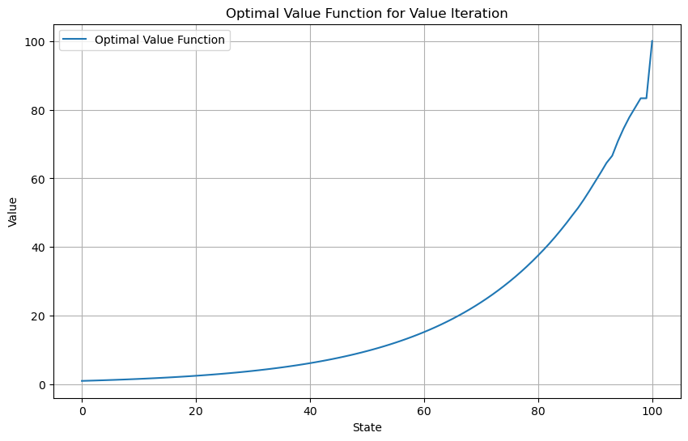

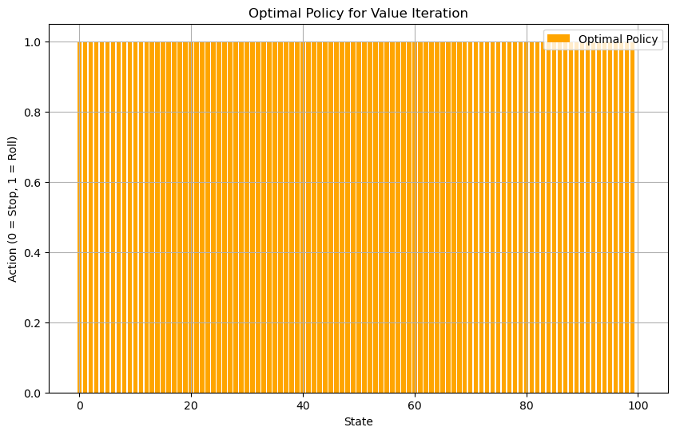

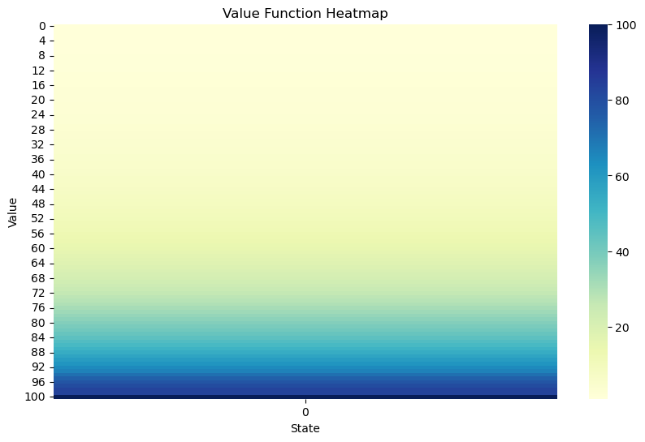

```python
# 4. Create a heatmap or line plot to visualize the value function over different states. How does the value function change as the state approaches the goal?

# Value Function Line Plot
plt.figure(figsize=(10, 6))
plt.plot(optimal_value_vi, label="Optimal Value Function")
plt.title("Optimal Value Function for Value Iteration")
plt.xlabel("State")
plt.ylabel("Value")
plt.legend()
plt.grid()
plt.show()

# Policy Bar Plot
plt.figure(figsize=(10, 6))
plt.bar(range(goal + 1), optimal_policy_vi, label="Optimal Policy", color='orange')
plt.title("Optimal Policy for Value Iteration")
plt.xlabel("State")
plt.ylabel("Action (0 = Stop, 1 = Roll)")
plt.legend()
plt.grid()
plt.show()

# Heatmap of Value Function
plt.figure(figsize=(10, 6))
sns.heatmap(optimal_value_vi.reshape(-1, 1), cmap="YlGnBu", cbar=True)
plt.title("Value Function Heatmap")
plt.xlabel("State")
plt.ylabel("Value")
plt.show()
```

# Conclusion (0.5M)

Conclude your assignment in 250 wrods by discussing the best approach for dice problem with the initial parameters and after chnaging the parameters.